# FoodHub_Project_Okesola_Moses_Olusola

Exploring relationship between either numerical variables or numerical variables and categorical variables.

**Cuisine type vs Cost of the order**

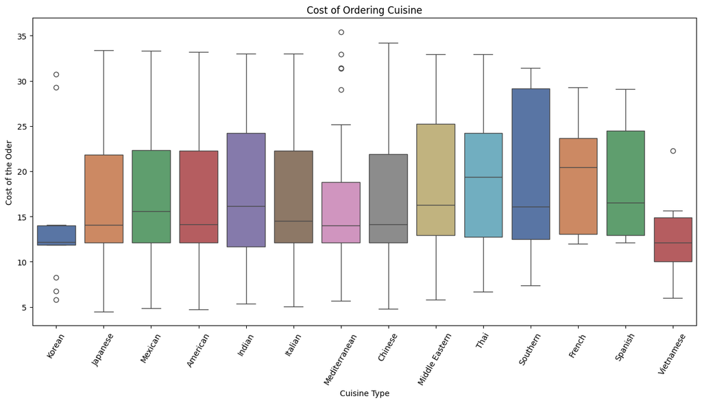

```python
# Relationship between cuisine type and  cost of order
plt.figure(figsize=(15,7))
# visualize the relationship between cuisine type and  cost of order using boxplot
sns.boxplot(x="cuisine_type", y="cost_of_the_order", data=FoodHub_data,hue="cuisine_type", palette='deep');
plt.xticks(rotation=60)
plt.xlabel("Cuisine Type")
plt.ylabel("Cost of the Oder")
plt.title("Cost of Ordering Cuisine")
plt.show()
```

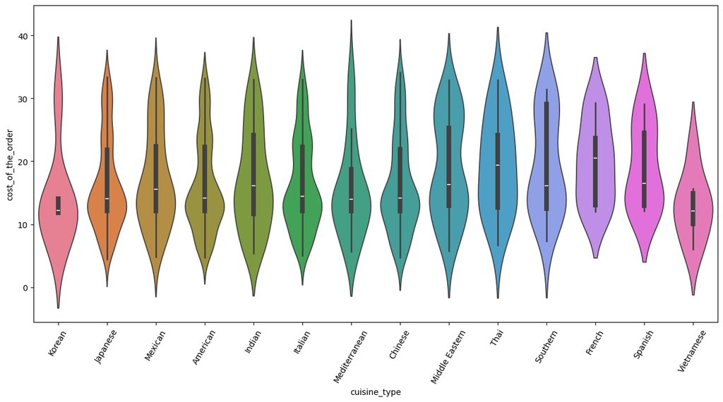

```python
# Relationship between cuisine type and  cost of order
plt.figure(figsize=(15,7))
# visualize the relationship between cuisine type and  cost of order using violin plot
sns.violinplot(x="cuisine_type", y="cost_of_the_order", data=FoodHub_data,hue="cuisine_type");
plt.xticks(rotation = 60);
```

- The white mark inside the violin plot shows the median cost of the order for each cuisine. The median varies from 12 to 20 dollars. The dark part shows the lower and upper quartiles of the cost of ordering any of the cuisines.
- The violin plot also shows their skewness as indicated in the boxplot above.

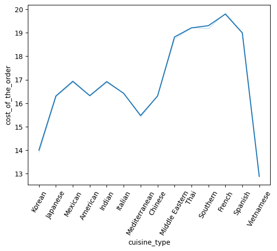

```python
# visualize the relationship between cuisine type and  cost of order using line plot
sns.lineplot(x="cuisine_type", y="cost_of_the_order", data=FoodHub_data, errorbar=('ci', False));
plt.xticks(rotation=60);
plt.show()
```

- The graph shows significant variation in the cost of the order across different cuisine types. The upward and downward movements show that there are differences in pricing among the cuisine types.
- The curve in the graph suggests that there are certain cuisine types where the cost of the order deviates from a linear trend.

**Cuisine type vs Food Preparation time**

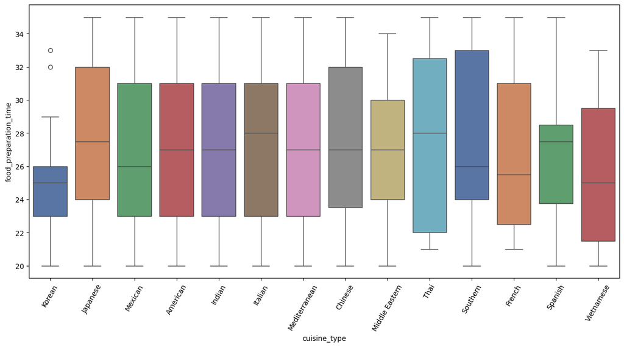

```python
# Relationship between cuisine type and  food preparation time
plt.figure(figsize=(15,7))
# visualize the relationship between cuisine type and  food preparation time using boxplot
sns.boxplot(x="cuisine_type", y="food_preparation_time", data=FoodHub_data, hue="cuisine_type", palette='deep');
plt.xticks(rotation=60)
plt.show()
```

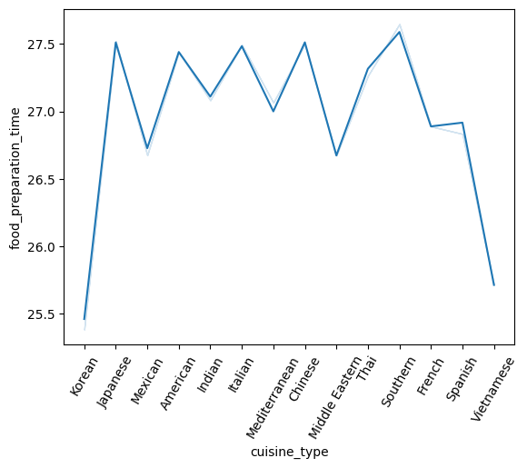

```python
# visualize the relationship between cuisine type and  food preparation time using line plot
sns.lineplot( x="cuisine_type",y="food_preparation_time", data=FoodHub_data, errorbar=('ci', False));
plt.xticks(rotation=60)
plt.show()
```

- Most cuisine types have the same maximum and minimum food preparation time.
- 75 percentiles of Southern cuisine take more time to prepare compared to 75 percentiles of Korean which is the least.
- Preparatory time for Korean cuisine has a minute outlier.
- Some groups of cuisine types have the same median preparation time.
- The plot suggests that preparation time for most cuisine types is consistent and predictable.

**Cuisine vs Delivery Time**

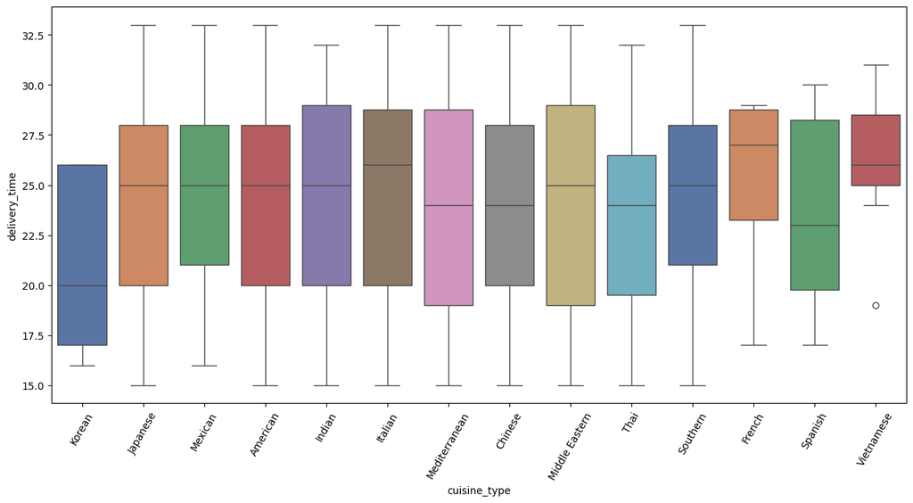

```python
# Relationship between Cuisine Type and Delivery time
plt.figure(figsize=(15,7))
# visualize the relationship between Cuisine Type and Delivery time using boxplot
sns.boxplot(x="cuisine_type", y="delivery_time", data=FoodHub_data, hue="cuisine_type",palette='deep');
plt.xticks(rotation=60)
plt.show()
```

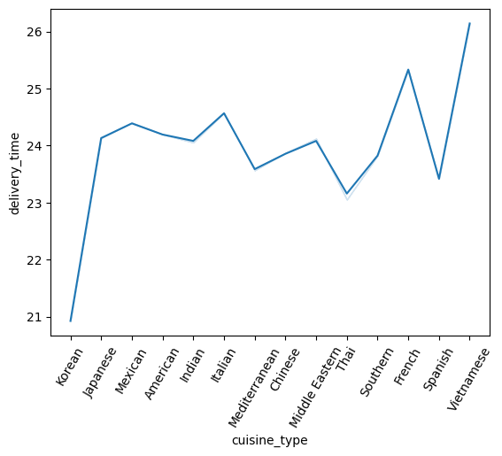

```python
# visualize the relationship between cuisine type and  delivery time using line plot
sns.lineplot(x="cuisine_type",y="delivery_time", data=FoodHub_data, errorbar=('ci', False));
plt.xticks(rotation=60)
plt.show()
```

The maximum delivery time is at 33 minutes, and the minimum is 15 minutes or slightly above.

There are variations in median of delivery time for one cuisine to another, but some cuisines have the same median delivery time.

**Cuisine Type vs Rating**

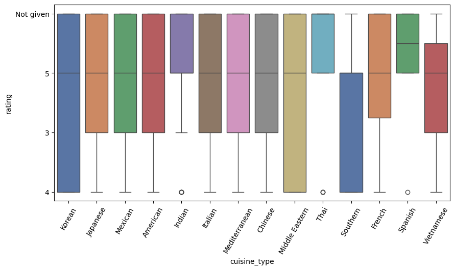

```python
# Relationship between Cuisine Type and Rating
plt.figure(figsize=(10,5))
# visualize the relationship between Cuisine Type and Delivery time using boxplot
sns.boxplot(x="cuisine_type", y="rating", data=FoodHub_data, hue="cuisine_type",palette='deep');
plt.xticks(rotation=60)
plt.show()
```

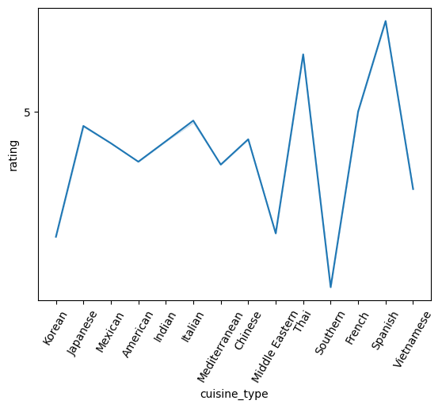

```python
# visualize the relationship between Cuisine Type and Rating using lineplot
sns.lineplot(x="cuisine_type", y="rating", data=FoodHub_data, errorbar=('ci', False));
plt.xticks(rotation=60)
plt.show()
```

- 10 cuisine types got the same rating of 5 from some customers.
- The rating '5' is also the median rating for the 10 cuisines mentioned above.
- The pattern suggests that there is some variation in the ratings of different cuisine types. The alternating upward and downward movements indicate that the ratings fluctuate across different cuisine types. The steep increase and subsequent decrease may indicate a significant change in rating for a particular cuisine type.
- The outliers are very few.

**Cuisine Type vs Day of The Week**

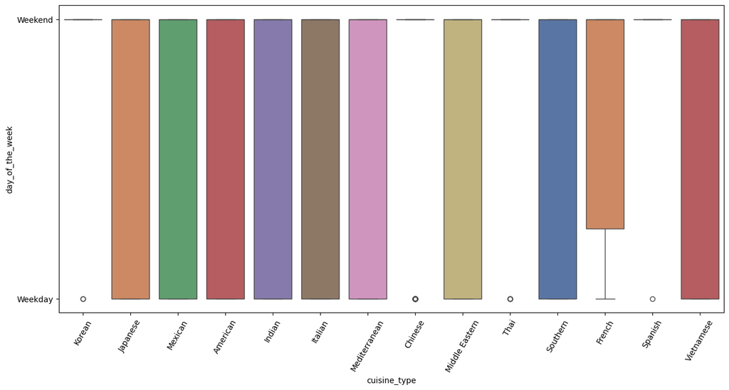

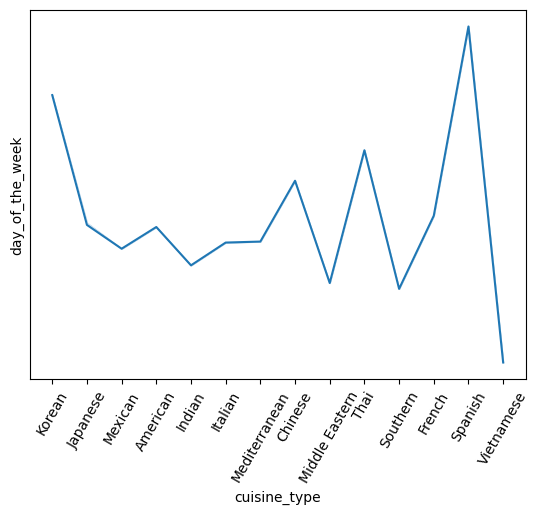

```python
# Relationship between Cuisine and Day of the Week
plt.figure(figsize=(15,7))
# visualize the relationship between Day of the Week and Day of the Week using boxplot and lineplot
sns.boxplot(  x= 'cuisine_type', y="day_of_the_week", data=FoodHub_data, hue="cuisine_type",palette='deep');
plt.xticks(rotation=60)
plt.show()

sns.lineplot(x="cuisine_type",y="day_of_the_week", data=FoodHub_data, errorbar=('ci', False));
plt.xticks(rotation=60)
plt.show()
```

There is an increase in the order of different cuisines during weekends than weekdays.

**Cost of Order vs Day of the Week**

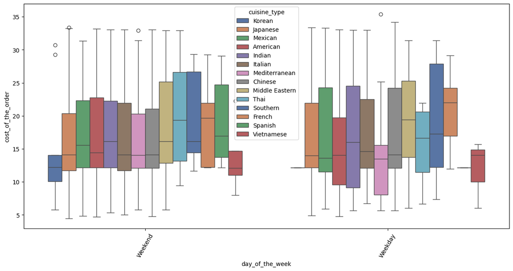

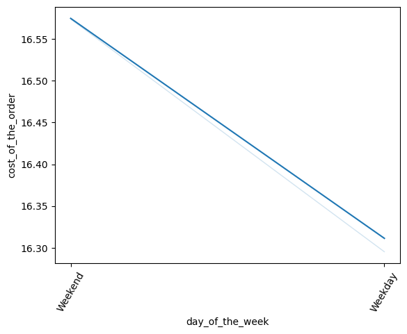

```python
# Relationship between Cost of order and Day of the Week
plt.figure(figsize=(15,7))
# visualize the relationship between Cost of order and Day of the Week using boxplot and lineplot
sns.boxplot(x="day_of_the_week", y="cost_of_the_order", data=FoodHub_data, hue="cuisine_type",palette='deep');
plt.xticks(rotation=60)
plt.show()

sns.lineplot(x="day_of_the_week",y="cost_of_the_order", data=FoodHub_data, errorbar=('ci', False));
plt.xticks(rotation=60)
plt.show()
```

The downward slope suggests that the cost of the order tends to be higher on weekends and lower on weekdays.